# AB Testing Project

Before we start the test, we need to conduct some preliminary calculations, so that we can easily insert the results into the function.

```r
total <- data %>% group_by(test.group) %>% count()

successes <- data %>% filter(made_purchase == 1) %>%
  group_by(test.group) %>% count()
```

We have created two data frames, columns from which will be derived to calculate the test statistics. Now, we can conduct the test.

```r
prop.test(successes$n, total$n, alternative = "greater", conf.level = 0.95)
```

```
    2-sample test for equality of proportions with continuity correction

data:  successes$n out of total$n
X-squared = 111.47, df = 1, p-value < 2.2e-16
alternative hypothesis: greater
95 percent confidence interval:
 0.0292177 1.0000000
sample estimates:
    prop 1     prop 2
0.06662242 0.03233925
```

As we can see, the p-value is less than 0.05, which means that we can reject the null hypothesis. This means that the ads have a significant impact on sales.

**Part 6: Data Visualization**

It is essential to prepare some visualizations for stakeholders to understand the results better. We will start by creating a bar chart to show the distribution of the test.group variable.

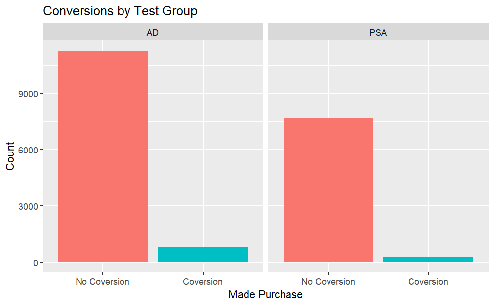

```r
bar_chart <- data %>% ggplot(aes(x = made_purchase)) + geom_bar(aes(fill = made_purchase), position = 'dodge') +
  labs(title = "Conversions by Test Group", x = "Made Purchase", y = "Count") + scale_x_discrete(breaks = c(FALSE,TRUE),                                                                   labels = c('No Coversion', 'Coversion')) +
  facet_wrap(~test.group) + theme(legend.position = "none")
bar_chart
```

This plot demonstrates that the experimental group has both a bigger amount of subjects and a higher conversion rate than the control group.

Next, we will create a histogram to show the conversions by the time of day.

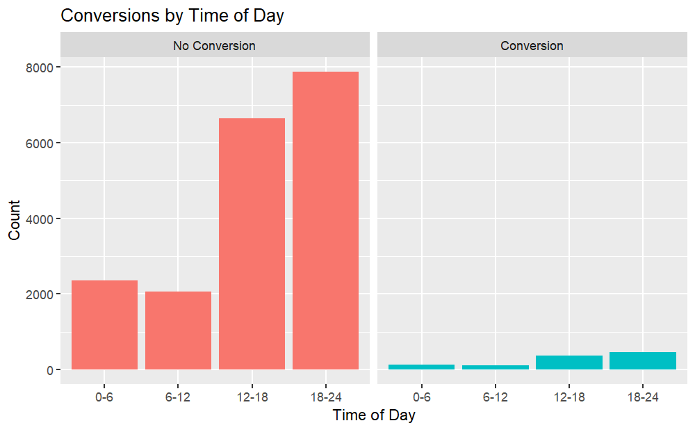

```r
histogram <- data %>% ggplot(aes(x = time_of_day)) + geom_histogram(aes(fill = made_purchase), stat = 'count') +
  labs(title = "Conversions by Time of Day", x = "Time of Day", y = "Count") +
  facet_wrap(~made_purchase, labeller = as_labeller(c('FALSE' = 'No Conversion',
                                                      'TRUE' = 'Conversion'))) + theme(legend.position = "none")
histogram
```

**Part 7: Conclusion**

In conclusion, the A/B test has shown that the ads have a significant impact on sales. The experimental group has a higher conversion rate than the control group. This means that the company should continue to use ads to increase sales.